# Analyze_ab_test_results_notebook

## Analyze A/B Test Results

- Introduction
- Part I - Probability
- Part II - A/B Test
- Part III - Regression
- Conclusion

### Introduction

For this project, I will be working to understand the results of an A/B test run by an e-commerce website. I will work through this notebook to help the company understand if they should implement the new page, keep the old page, or perhaps run the experiment longer to make their decision.

#### Part I - Probability

To get started, let's import our libraries.

```python
import pandas as pd
import numpy as np
import random
import matplotlib.pyplot as plt
%matplotlib inline
#We are setting the seed to assure you get the same answers on quizzes as we set up
random.seed(42)
```

I will read in the dataset and take a look at the top few rows.

```python
df = pd.read_csv('ab_data.csv')
df.head()
```

|  | user_id | timestamp | group | landing_page | converted |
| --- | --- | --- | --- | --- | --- |
| 0 | 851104 | 2017-01-21 22:11:48.556739 | control | old_page | 0 |
| 1 | 804228 | 2017-01-12 08:01:45.159739 | control | old_page | 0 |
| 2 | 661590 | 2017-01-11 16:55:06.154213 | treatment | new_page | 0 |
| 3 | 853541 | 2017-01-08 18:28:03.143765 | treatment | new_page | 0 |
| 4 | 864975 | 2017-01-21 01:52:26.210827 | control | old_page | 1 |

```python
df.shape
```

```
(294478, 5)
```

```python
df.user_id.nunique()
```

```
290584
```

```python
df.drop_duplicates('user_id').converted.mean()
```

```
0.11956955647936569
```

```python
not_match = df.query('(group == "treatment" and landing_page != "new_page") or (group != "treatment" and landing_page == "new_page")')
not_match.shape
```

```
(3893, 5)
```

`new_page` and `treatment` don't match **3,893** times.

```python
pd.isnull(df).any()
```

```
user_id         False
timestamp       False
group           False
landing_page    False
converted       False
dtype: bool
```

No rows have missing values.

I will drop all the rows where `new_page` and `treatment` don't match, and store the new dataframe in **df2**.

```python
df2 = df.drop(df.query('(group == "treatment" and landing_page != "new_page") or (group != "treatment" and landing_page == "new_page")').index)
```

```python
# Double Check all of the correct rows were removed - this should be 0
df2[((df2['group'] == 'treatment') == (df2['landing_page'] == 'new_page')) == False].shape[0]
```

```
0
```

```python
df2.user_id.nunique()
```

```
290584
```

There are **290,584** unique `user_id`s in **df2**.

The only `user_id` that is repeated in **df2** is the one we see below.

```python
df2.shape
```

```
(290585, 5)
```

```python
df2[df2.duplicated(subset=['user_id'])]
```

|  | user_id | timestamp | group | landing_page | converted |
| --- | --- | --- | --- | --- | --- |
| 2893 | 773192 | 2017-01-14 02:55:59.590927 | treatment | new_page | 0 |

```python
df2.query('user_id == "773192"')
```

|  | user_id | timestamp | group | landing_page | converted |
| --- | --- | --- | --- | --- | --- |
| 1899 | 773192 | 2017-01-09 05:37:58.781806 | treatment | new_page | 0 |
| 2893 | 773192 | 2017-01-14 02:55:59.590927 | treatment | new_page | 0 |

Since both rows contain the same information in the relevant columns, we will remove one of them.

```python
df2 = df2.drop_duplicates(subset=['user_id'])
df2.shape
```

```
(290584, 5)
```

```python
p_conv = df2.converted.mean()
p_conv
```

```
0.11959708724499628
```

```python
p_conv_cont = df2.query('group == "control"').converted.mean()
p_conv_cont
```

```
0.1203863045004612
```

```python
p_conv_treat = df2.query('group == "treatment"').converted.mean()
p_conv_treat
```

```
0.11880806551510564
```

```python
p_new_page = df2.query('landing_page == "new_page"').shape[0] / df2.shape[0]
p_new_page
```

```
0.5000619442226688
```

From the results seen earlier we can say that there is not sufficient evidence to conclude that the `treatment` page leads to more conversions.

Even though `new_page` was given to half the users, the users that were in the `treatment` group and were converted were only **11.88%**, and the users that were in the `control` group and were converted were only **12.04%**.

If we want to assume that the old page is better unless the new page proves to be definitely better at a Type I error rate of 5%, our null and alternative hypotheses should be as follows:

**$$H_0: p_{old} \geqslant p_{new} $$ $$H_1: p_{old} < p_{new} $$**

With **$p_{old}$** and **$p_{new}$** being the converted rates for the old and new pages.

I will now assume under the null hypothesis, $p_{new}$ and $p_{old}$ both have "true" success rates equal to the **converted** success rate regardless of page - that is $p_{new}$ and $p_{old}$ are equal. Furthermore, I will assume they are equal to the **converted** rate in **ab_data.csv** regardless of the page.

I will use a sample size for each page equal to the ones in **ab_data.csv**.

Then I will perform the sampling distribution for the difference in **converted** between the two pages over 10,000 iterations of calculating an estimate from the null.

```python
p_new = df2.converted.mean()
p_new
```

```
0.11959708724499628
```

```python
p_old = df2.converted.mean()
p_old
```

```
0.11959708724499628
```

```python
n_new = df2.query('group == "treatment"').shape[0]
n_new
```

```
145310
```

$n_{new}$, the number of individuals in the treatment group, is **145,310**.

```python
n_old = df2.query('group == "control"').shape[0]
n_old
```

```
145274
```

I will simulate $n_{new}$ transactions with a conversion rate of $p_{new}$ under the null and store these $n_{new}$ 1's and 0's in **new_page_converted**.

```python
new_page_converted = np.random.binomial(1, p_new, n_new)
new_page_converted
```

```
array([1, 0, 0, ..., 0, 0, 0])
```

I will simulate $n_{old}$ transactions with a conversion rate of $p_{old}$ under the null and store these $n_{old}$ 1's and 0's in **old_page_converted**.

```python
old_page_converted = np.random.binomial(1, p_old, n_old)
old_page_converted
```

```
array([0, 0, 1, ..., 0, 0, 0])
```

```python
new_page_converted.mean() - old_page_converted.mean()
```

```
-0.0027550794698711634
```

I will create 10,000 $p_{new}$ - $p_{old}$ values using the same simulation process I used above and store all 10,000 values in a NumPy array called **p_diffs**.

```python
p_diffs = []

for i in range(10000):
    new_page_converted = np.random.binomial(n_new, p_new)
    old_page_converted = np.random.binomial(n_old, p_old)
    diff = new_page_converted - old_page_converted
    p_diffs.append(diff)
```

```python
new_converted_simulation = np.random.binomial(n_new, p_new, 10000)/n_new
old_converted_simulation = np.random.binomial(n_old, p_old, 10000)/n_old
p_diffs = new_converted_simulation - old_converted_simulation
```

I will plot a histogram of the **p_diffs**.

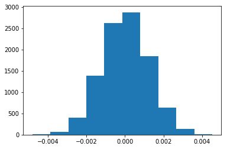

```python
plt.hist(p_diffs);
```

j. What proportion of the **p_diffs** are greater than the actual difference observed in **ab_data.csv**?

```python
obs_diff = p_conv_treat - p_conv_cont
obs_diff
```

```
-0.0015782389853555567
```

```python
p_val = (p_diffs > obs_diff).mean()
p_val
```

```
0.90590000000000004
```

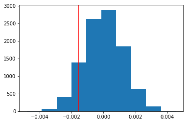

```python
plt.hist(p_diffs)
plt.axvline(obs_diff, color='r');
```

In the last part I computed what is called the `p value`. This value is used to reject or fail to reject the null hypothesis. It is calculated by first assuming that the null hypothesis is correct, and then calculating the probability of obtaining values that are equal or more extreme than the values in the null hypothesis.

Since our `p-value` is *a lot* larger than **0.05** (our Type I error rate tolerance), we fail to reject the null.

Now I will use a built-in function to achieve similar results.

```python
import statsmodels.api as sm

convert_old = df2.query('landing_page == "old_page" and converted == "1"').shape[0]
convert_new = df2.query('landing_page == "new_page" and converted == "1"').shape[0]
n_old = df2.query('landing_page == "old_page"').shape[0]
n_new = df2.query('landing_page == "new_page"').shape[0]
```

I will use use `stats.proportions_ztest` to compute your test statistic and p-value.

```python
z_test , p_value = sm.stats.proportions_ztest([convert_old, convert_new],
                                              [n_old, n_new], alternative='smaller')

print(z_test, p_value)
```

```
1.31092419842 0.905058312759
```

The `z-score` is a critical value that we can use when we have a normal distribution. It tells you how many standard deviations you are away from the mean. Our `z-score` is $\approx$ **1.31**, that means that we are **1.31** standard deviations away from the mean.

If we check the `z-score` percentile table, we can see that with a `z-score` of **1.31** our p-value is between **0.90** and **0.91**, which is what the function gave us as well.

Since our p-value is almost exactly the same as the one we got earlier, we reach the same conclusion. That is, we fail to reject the null.

Also, in this situation, having a `z-score` that is less than the z-critical value of **1.6** means that we are likely to sample such a sample from the sample distribution given an alpha of **0.05**.

### Part III - A regression approach

In this final part, I will achieve the result I achieved in the A/B test in Part II above by performing regression.

Since each row is either a conversion or no conversion, we should be performing **Logistic Regression**.

I will use `statsmodels` to fit the regression model I specified previously to see if there is a significant difference in `conversion` based on which page a customer receives.

I will first create in **df2** a column for the intercept, and create a dummy variable column for which page each user received. The `ab_page` column will be 1 when an individual receives the `treatment` and 0 when it receives `control`.

```python
df2['intercept'] = 1
df2['ab_page'] = (df2.group == 'treatment').astype(int)
```

```python
model = sm.Logit(df2.converted, df2[['intercept', 'ab_page']])
```

```python
result = model.fit()
result.summary2()
```

```
Optimization terminated successfully.
         Current function value: 0.366118
         Iterations 6
```

| Model: | Logit | No. Iterations: | 6.0000 |
| --- | --- | --- | --- |
| Dependent Variable: | converted | Pseudo R-squared: | 0.000 |
| Date: | 2021-04-10 11:01 | AIC: | 212780.3502 |
| No. Observations: | 290584 | BIC: | 212801.5095 |
| Df Model: | 1 | Log-Likelihood: | -1.0639e+05 |
| Df Residuals: | 290582 | LL-Null: | -1.0639e+05 |
| Converged: | 1.0000 | Scale: | 1.0000 |

|  | Coef. | Std.Err. | z | P>\|z\| | [0.025 | 0.975] |
| --- | --- | --- | --- | --- | --- | --- |
| intercept | -1.9888 | 0.0081 | -246.6690 | 0.0000 | -2.0046 | -1.9730 |
| ab_page | -0.0150 | 0.0114 | -1.3109 | 0.1899 | -0.0374 | 0.0074 |

The p-value associated with `ab_page` is **0.1899**. The p-value I found previously in part II is **0.90**. This difference is due to the fact that with logistic regression we are using a different null and alternative hypothesis. Our null and alternative hypothesis from part II were as follows:

**$$H_0: p_{old} \geqslant p_{new} $$ $$H_1: p_{old} < p_{new} $$**

And now they are as follows:

**$$H_0: p_{old} = p_{new} $$ $$H_1: p_{old} \neq p_{new} $$**

Therefore, since our p-value is higher than **0.05**, we fail to reject the null, and we say that ab_page is not affecting the conversion probability.

Another reason the value differs from the value I found in part II because here I am performing a **two-tailed test** and before I performed a **one-tailed test**.

On one hand, based on the p-value we found we don´t have statistical significance to suggest that there is a relationship between landing page (`ab_page`) and `conversion`. It would be a good idea to consider other factors into the regression model, it would enhance the **R-squared** value and at the same time reduce the **standard error**. Therefore it will better explain the variation of the response variable. This is because other variables may influence the conversion instead of the landing page.

One problem that we might have while adding additional terms is **collinearity**. This means that the terms we are using could be related to eachother and, if this happens, our results won't be reliable. We want our predictor variables to correlate with our response variable, we don't want our predictor variables relating to eachother. This can be solved by comparing the **VIF** of the predictor variables and removing one of the variable that is correlated to another one.

Also our variables could not be linearly related. In that case, we might have to consider higher order terms (like quadratics, cubics, or intersected variables).

I will now add an effect based on which country a user lives in. I will first read the **countries.csv** dataset and merge together my datasets.

```python
countries = pd.read_csv('countries.csv')
countries.head(2)
```

|  | user_id | country |
| --- | --- | --- |
| 0 | 834778 | UK |
| 1 | 928468 | US |

```python
df3 = df2.merge(countries, on='user_id')
df3.head(2)
```

|  | user_id | timestamp | group | landing_page | converted | intercept | ab_page | country |
| --- | --- | --- | --- | --- | --- | --- | --- | --- |
| 0 | 851104 | 2017-01-21 22:11:48.556739 | control | old_page | 0 | 1 | 0 | US |
| 1 | 804228 | 2017-01-12 08:01:45.159739 | control | old_page | 0 | 1 | 0 | US |

```python
country_dummies = pd.get_dummies(df3['country'])
df_new = df3.join(country_dummies)
df_new.head()
```

|  | user_id | timestamp | group | landing_page | converted | intercept | ab_page | country | CA | UK | US |
| --- | --- | --- | --- | --- | --- | --- | --- | --- | --- | --- | --- |
| 0 | 851104 | 2017-01-21 22:11:48.556739 | control | old_page | 0 | 1 | 0 | US | 0 | 0 | 1 |
| 1 | 804228 | 2017-01-12 08:01:45.159739 | control | old_page | 0 | 1 | 0 | US | 0 | 0 | 1 |
| 2 | 661590 | 2017-01-11 16:55:06.154213 | treatment | new_page | 0 | 1 | 1 | US | 0 | 0 | 1 |
| 3 | 853541 | 2017-01-08 18:28:03.143765 | treatment | new_page | 0 | 1 | 1 | US | 0 | 0 | 1 |
| 4 | 864975 | 2017-01-21 01:52:26.210827 | control | old_page | 1 | 1 | 0 | US | 0 | 0 | 1 |

```python
df_new['intercept'] = 1
model = sm.Logit(df_new.converted, df_new[['intercept', 'CA', 'UK']])
result = model.fit()
result.summary2()
```

```
Optimization terminated successfully.
         Current function value: 0.366116
         Iterations 6
```

| Model: | Logit | No. Iterations: | 6.0000 |
| --- | --- | --- | --- |
| Dependent Variable: | converted | Pseudo R-squared: | 0.000 |
| Date: | 2021-04-10 11:01 | AIC: | 212780.8333 |
| No. Observations: | 290584 | BIC: | 212812.5723 |
| Df Model: | 2 | Log-Likelihood: | -1.0639e+05 |
| Df Residuals: | 290581 | LL-Null: | -1.0639e+05 |
| Converged: | 1.0000 | Scale: | 1.0000 |

|  | Coef. | Std.Err. | z | P>\|z\| | [0.025 | 0.975] |
| --- | --- | --- | --- | --- | --- | --- |
| intercept | -1.9967 | 0.0068 | -292.3145 | 0.0000 | -2.0101 | -1.9833 |
| CA | -0.0408 | 0.0269 | -1.5178 | 0.1291 | -0.0935 | 0.0119 |
| UK | 0.0099 | 0.0133 | 0.7458 | 0.4558 | -0.0161 | 0.0360 |

```python
np.exp(-0.0408), np.exp(0.0099)
```

```
(0.96002111497165088, 1.0099491671175422)
```

I will now look at an interaction between `page` and `country` to see if there are significant effects on `conversion`.

```python
df_new['intercept'] = 1
df_new['ab_page_CA'] = df_new['ab_page'] * df_new['CA']
df_new['ab_page_UK'] = df_new['ab_page'] * df_new['UK']

model = sm.Logit(df_new.converted, df_new[['intercept', 'CA', 'UK',
                                           'ab_page', 'ab_page_CA',
                                           'ab_page_UK']])
result = model.fit()
result.summary2()
```

```
Optimization terminated successfully.
         Current function value: 0.366109
         Iterations 6
```

| Model: | Logit | No. Iterations: | 6.0000 |
| --- | --- | --- | --- |
| Dependent Variable: | converted | Pseudo R-squared: | 0.000 |
| Date: | 2021-04-10 11:01 | AIC: | 212782.6602 |
| No. Observations: | 290584 | BIC: | 212846.1381 |
| Df Model: | 5 | Log-Likelihood: | -1.0639e+05 |
| Df Residuals: | 290578 | LL-Null: | -1.0639e+05 |
| Converged: | 1.0000 | Scale: | 1.0000 |

|  | Coef. | Std.Err. | z | P>\|z\| | [0.025 | 0.975] |
| --- | --- | --- | --- | --- | --- | --- |
| intercept | -1.9865 | 0.0096 | -206.3440 | 0.0000 | -2.0053 | -1.9676 |
| CA | -0.0175 | 0.0377 | -0.4652 | 0.6418 | -0.0914 | 0.0563 |
| UK | -0.0057 | 0.0188 | -0.3057 | 0.7598 | -0.0426 | 0.0311 |
| ab_page | -0.0206 | 0.0137 | -1.5052 | 0.1323 | -0.0473 | 0.0062 |
| ab_page_CA | -0.0469 | 0.0538 | -0.8718 | 0.3833 | -0.1523 | 0.0585 |
| ab_page_UK | 0.0314 | 0.0266 | 1.1807 | 0.2377 | -0.0207 | 0.0835 |

### Conclusion

Therefore, we can conclude that there is *no difference* between the old and the new page, and the company should **mantain** the old page.

```python
from subprocess import call
call(['python', '-m', 'nbconvert', 'Analyze_ab_test_results_notebook.ipynb'])
```

```
0
```